# NOAAnalysis

Katalin Virag

2017-12-20

These functions can be used to work with the NOAA Significant Earthquakes dataset from [link](https://www.ngdc.noaa.gov/nndc/struts/form?t=101650&s=1&d=1).

## Functions included in the package

- `eq_clean_data()` to clean data
- `eq_location_clean()` to clean the `LOCATION_NAME` column of the NOAA data
- `geom_timeline()` to visualize the times at which earthquakes occur
- `geom_timeline_label()` to add annotation to the timeline plot of earthquakes
- `theme_timeline` to add simple theme to the timeline plot of earthquakes
- `eq_map()` to visualize the earthquakes in space
- `eq_create_label()` to create an HTML label to annotate the leaflet map

## Data

This package includes one dataset called `signif.txt` which contains information on destructive earthquakes (see [link](https://www.ngdc.noaa.gov/nndc/struts/form?t=101650&s=1&d=1)).

## Data cleaning functions

### Clean the NOAA Significant Earthquake Database with `eq_clean_data()`

This function takes raw NOAA data frame and returns a clean data frame with the following features:

- A `DATE` column created by uniting the year, month, day and converting it to the `Date` class
- `LATITUDE` and `LONGITUDE` columns converted to `numeric` class
- `LOCATION_NAME_cleaned` column from `LOCATION_NAME` by stripping out the country name and in title case

```r
noaa <- readr::read_delim(system.file("extdata", "signif.txt",
        package = "NOAAnalysis"), delim = "\t") %>% eq_clean_data()
head(noaa)
```

```
## # A tibble: 6 x 49
##     I_D FLAG_TSUNAMI        DATE  YEAR MONTH   DAY  HOUR MINUTE SECOND
##   <int>        <chr>      <date> <int> <dbl> <dbl> <int>  <int>  <chr>
## 1     1         <NA> -2150-01-01 -2150     1     1    NA     NA
## 2     3         <NA> -2000-01-01 -2000     1     1    NA     NA   <NA>
## 3     2          Tsu -2000-01-01 -2000     1     1    NA     NA   <NA>
## 4  5877          Tsu -1610-01-01 -1610     1     1    NA     NA   <NA>
## 5     8         <NA> -1566-01-01 -1566     1     1    NA     NA
## 6    11         <NA> -1450-01-01 -1450     1     1    NA     NA   <NA>
## # ... with 40 more variables: COUNTRY <chr>, STATE <chr>,
## #   LOCATION_NAME <chr>, LOCATION_NAME_cleaned <chr>, LATITUDE <dbl>,
## #   LONGITUDE <dbl>, REGION_CODE <int>, FOCAL_DEPTH <int>,
## #   EQ_PRIMARY <chr>, EQ_MAG_MW <chr>, EQ_MAG_MS <chr>, EQ_MAG_MB <chr>,
## #   EQ_MAG_ML <dbl>, EQ_MAG_MFA <chr>, EQ_MAG_UNK <chr>, INTENSITY <int>,
## #   DEATHS <chr>, DEATHS_DESCRIPTION <int>, MISSING <chr>,
## #   MISSING_DESCRIPTION <int>, INJURIES <chr>, INJURIES_DESCRIPTION <int>,
## #   DAMAGE_MILLIONS_DOLLARS <chr>, DAMAGE_DESCRIPTION <int>,
## #   HOUSES_DESTROYED <int>, HOUSES_DESTROYED_DESCRIPTION <int>,
## #   HOUSES_DAMAGED <int>, HOUSES_DAMAGED_DESCRIPTION <int>,
## #   TOTAL_DEATHS <chr>, TOTAL_DEATHS_DESCRIPTION <int>,
## #   TOTAL_MISSING <chr>, TOTAL_MISSING_DESCRIPTION <chr>,
## #   TOTAL_INJURIES <int>, TOTAL_INJURIES_DESCRIPTION <int>,
## #   TOTAL_DAMAGE_MILLIONS_DOLLARS <chr>, TOTAL_DAMAGE_DESCRIPTION <int>,
## #   TOTAL_HOUSES_DESTROYED <int>,
## #   TOTAL_HOUSES_DESTROYED_DESCRIPTION <int>, TOTAL_HOUSES_DAMAGED <int>,
## #   TOTAL_HOUSES_DAMAGED_DESCRIPTION <int>
```

```r
summary(noaa)
```

```
##       I_D        FLAG_TSUNAMI            DATE                  YEAR
##  Min.   :    1   Length:5979        Min.   :-2150-01-01   Min.   :-2150
##  1st Qu.: 2104   Class :character   1st Qu.:1812-12-14    1st Qu.: 1812
##  Median : 4538   Mode  :character   Median :1925-05-07    Median : 1925
##  Mean   : 4570                      Mean   :1799-06-07    Mean   : 1799
##  3rd Qu.: 6390                      3rd Qu.:1984-04-26    3rd Qu.: 1984
##  Max.   :10285                      Max.   :2017-11-23    Max.   : 2017
##
##      MONTH            DAY             HOUR          MINUTE
##  Min.   : 1.00   Min.   : 1.00   Min.   : 0.0   Min.   : 0.00
##  1st Qu.: 3.00   1st Qu.: 6.00   1st Qu.: 5.0   1st Qu.:14.00
##  Median : 6.00   Median :14.00   Median :11.0   Median :29.00
##  Mean   : 6.14   Mean   :14.38   Mean   :11.3   Mean   :28.77
##  3rd Qu.: 9.00   3rd Qu.:23.00   3rd Qu.:17.0   3rd Qu.:43.00
##  Max.   :12.00   Max.   :31.00   Max.   :23.0   Max.   :59.00
##                                  NA's   :2028   NA's   :2233
##     SECOND            COUNTRY             STATE
##  Length:5979        Length:5979        Length:5979
##  Class :character   Class :character   Class :character
##  Mode  :character   Mode  :character   Mode  :character
##
##
##
##
##  LOCATION_NAME      LOCATION_NAME_cleaned    LATITUDE
##  Length:5979        Length:5979           Min.   :-62.88
##  Class :character   Class :character      1st Qu.: 10.04
##  Mode  :character   Mode  :character      Median : 32.46
##                                           Mean   : 22.64
##                                           3rd Qu.: 38.80
##                                           Max.   : 73.12
##                                           NA's   :54
##    LONGITUDE        REGION_CODE     FOCAL_DEPTH      EQ_PRIMARY
##  Min.   :-179.98   Min.   : 10.0   Min.   :  0.00   Length:5979
##  1st Qu.:  -8.00   1st Qu.: 50.0   1st Qu.: 11.00   Class :character
##  Median :  43.20   Median :130.0   Median : 27.00   Mode  :character
##  Mean   :  37.88   Mean   :109.9   Mean   : 41.85
##  3rd Qu.: 115.30   3rd Qu.:160.0   3rd Qu.: 40.00
##  Max.   : 180.00   Max.   :170.0   Max.   :678.00
##  NA's   :50                        NA's   :2949
```

[output cut: 73 more lines]

```
##  Min.   :      1        Min.   :1.00
##  1st Qu.:     73        1st Qu.:2.00
##  Median :    592        Median :3.00
##  Mean   :  19580        Mean   :2.72
##  3rd Qu.:   4040        3rd Qu.:4.00
##  Max.   :5360000        Max.   :4.00
##  NA's   :5230           NA's   :4313
##  TOTAL_HOUSES_DAMAGED TOTAL_HOUSES_DAMAGED_DESCRIPTION
##  Min.   :       1     Min.   : 1.000
##  1st Qu.:      70     1st Qu.: 1.000
##  Median :     597     Median : 2.000
##  Mean   :   75009     Mean   : 2.429
##  3rd Qu.:    2500     3rd Qu.: 3.000
##  Max.   :21000000     Max.   :34.000
##  NA's   :5658         NA's   :5347
```

### Clean the LOCATION_NAME string with `eq_location_clean()`

This helper function cleans the `LOCATION_NAME` string by stripping out the country name and converts names to title case

```r
eq_location_clean("SYRIA: UGARIT")
```

```
## [1] "Ugarit"
```

## Visualization tools

### Visualize the earthquakes in time with `geom_timeline()` and apply simple theme with `theme_timeline`

The `geom_timeline()` function creates a `ggplot` object which shows the times at which earthquakes occur ranging from `xmin` to `xmax` dates with a point for each earthquake. The `x` aesthetic is a date and an optional `y` aesthetic is a factor indicating some stratification (e.g. country). Additionally, the magnitudes and the number of deaths associated with each earthquake can be shown.

The `theme_timeline` creates simple theme for the timeline plot.

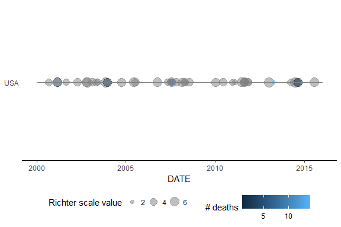

```r
readr::read_delim(system.file("extdata", "signif.txt",
       package = "NOAAnalysis"), delim = "\t") %>%
eq_clean_data() %>%
dplyr::filter(COUNTRY == "USA" & YEAR >= 2000) %>%
ggplot2::ggplot(ggplot2::aes(x = DATE, y = COUNTRY,
         xmin = as.Date("2000-01-01"), xmax = as.Date("2016-01-01"),
         size = as.numeric(EQ_PRIMARY), color = as.numeric(TOTAL_DEATHS))) +
geom_timeline() +
theme_timeline +
ggplot2::labs(colour = "# deaths", size = "Richter scale value")
```

Annotations can be added to the timeline plot with the `geom_timeline_label()` function. There is an option to subset to `n_max` number of earthquakes, where we take the `n_max` largest (by magnitude) earthquakes.

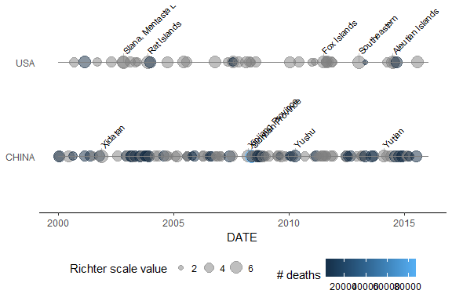

```r
readr::read_delim(system.file("extdata", "signif.txt",
       package = "NOAAnalysis"), delim = "\t") %>%
eq_clean_data() %>%
dplyr::filter(COUNTRY %in% c("USA", "CHINA") & YEAR >= 2000) %>%
ggplot2::ggplot(ggplot2::aes(x = DATE, y = COUNTRY,
                xmin = as.Date("2000-01-01"), xmax = as.Date("2016-01-01"),
                size = as.numeric(EQ_PRIMARY), color = as.numeric(TOTAL_DEATHS))) +
geom_timeline() +
geom_timeline_label(ggplot2::aes(label = LOCATION_NAME_cleaned)) +
theme_timeline +
ggplot2::labs(colour = "# deaths", size = "Richter scale value")
```

### Visualize the earthquakes in space with `eq_map()`

`eq_map()` creates a `leaflet` object which maps and annotates the epicenters. Each earthquake is shown with a circle, and the radius of the circle is proportional to the earthquake’s magnitude. Each point is annotated in pop up window containing annotation data stored in the `annot_col` column of data.

```r
readr::read_delim(system.file("extdata", "signif.txt",
       package = "NOAAnalysis"), delim = "\t") %>%
eq_clean_data() %>%
dplyr::filter(COUNTRY == "MEXICO" & YEAR >= 2000) %>%
eq_map(annot_col = "DATE")
```

[interactive chart not shown]

More annotation can be added to the `leaflet` map with the `eq_create_label()` function. This function puts together a character string for each earthquake that showes the cleaned location, the magnitude, and the total number of deaths (if not missing).

```r
readr::read_delim(system.file("extdata", "signif.txt",
       package = "NOAAnalysis"), delim = "\t") %>%
eq_clean_data() %>%
dplyr::filter(COUNTRY == "MEXICO" & YEAR >= 2000) %>%
dplyr::mutate(popup_text = eq_create_label(.)) %>%
eq_map(annot_col = "popup_text")
```

[interactive chart not shown]